# EDA White Wine Dataset

Jatin Rai

29/07/2020

### Loading Libraries

```r
library(ggplot2)
library(gridExtra)
library(GGally)
library(doBy)
library(corrplot)
```

### Loading the dataset

```r
wd <- read.csv('winequality-white.csv',sep = ';')
head(wd)
```

```
##   fixed.acidity volatile.acidity citric.acid residual.sugar chlorides
## 1           7.0             0.27        0.36           20.7     0.045
## 2           6.3             0.30        0.34            1.6     0.049
## 3           8.1             0.28        0.40            6.9     0.050
## 4           7.2             0.23        0.32            8.5     0.058
## 5           7.2             0.23        0.32            8.5     0.058
## 6           8.1             0.28        0.40            6.9     0.050
##   free.sulfur.dioxide total.sulfur.dioxide density   pH sulphates alcohol
## 1                  45                  170  1.0010 3.00      0.45     8.8
## 2                  14                  132  0.9940 3.30      0.49     9.5
## 3                  30                   97  0.9951 3.26      0.44    10.1
## 4                  47                  186  0.9956 3.19      0.40     9.9
## 5                  47                  186  0.9956 3.19      0.40     9.9
## 6                  30                   97  0.9951 3.26      0.44    10.1
##   quality
## 1       6
## 2       6
## 3       6
## 4       6
## 5       6
## 6       6
```

### Data Structure and data types

```r
str(wd)
```

```
## 'data.frame':    4898 obs. of  12 variables:
##  $ fixed.acidity       : num  7 6.3 8.1 7.2 7.2 8.1 6.2 7 6.3 8.1 ...
##  $ volatile.acidity    : num  0.27 0.3 0.28 0.23 0.23 0.28 0.32 0.27 0.3 0.22 ...
##  $ citric.acid         : num  0.36 0.34 0.4 0.32 0.32 0.4 0.16 0.36 0.34 0.43 ...
##  $ residual.sugar      : num  20.7 1.6 6.9 8.5 8.5 6.9 7 20.7 1.6 1.5 ...
##  $ chlorides           : num  0.045 0.049 0.05 0.058 0.058 0.05 0.045 0.045 0.049 0.044 ...
##  $ free.sulfur.dioxide : num  45 14 30 47 47 30 30 45 14 28 ...
##  $ total.sulfur.dioxide: num  170 132 97 186 186 97 136 170 132 129 ...
##  $ density             : num  1.001 0.994 0.995 0.996 0.996 ...
##  $ pH                  : num  3 3.3 3.26 3.19 3.19 3.26 3.18 3 3.3 3.22 ...
##  $ sulphates           : num  0.45 0.49 0.44 0.4 0.4 0.44 0.47 0.45 0.49 0.45 ...
##  $ alcohol             : num  8.8 9.5 10.1 9.9 9.9 10.1 9.6 8.8 9.5 11 ...
##  $ quality             : int  6 6 6 6 6 6 6 6 6 6 ...
```

### Checking for missing values

```r
sum(is.na(wd))
```

```
## [1] 0
```

### Univariate Plots

Quick view about the distribution of the quality rates

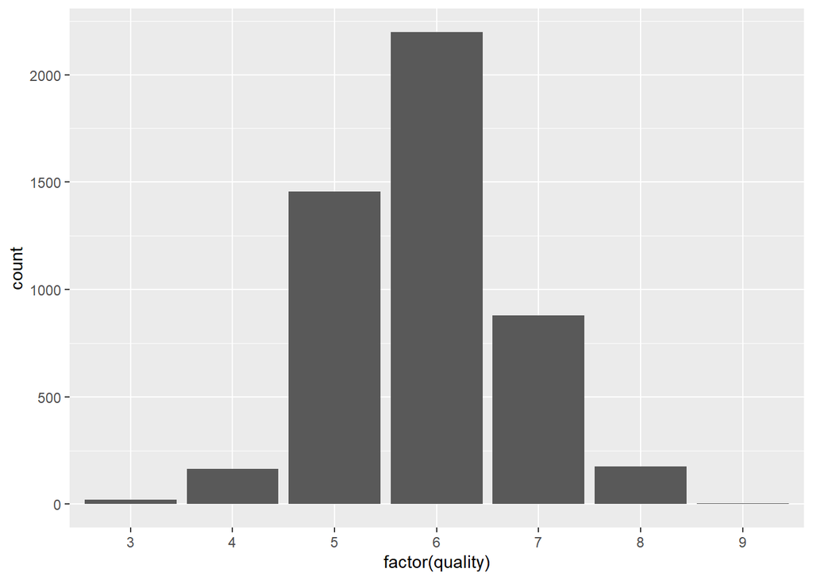

```r
ggplot(wd, aes(factor(quality)))+
  geom_bar()
```

```r
summary(wd$quality)
```

```
##    Min. 1st Qu.  Median    Mean 3rd Qu.    Max.
##   3.000   5.000   6.000   5.878   6.000   9.000
```

I got a normally distributed histogram, most wine have a quality between 5 and 7, the tallest clusters of bars is 6, representing the most common quality. Based on my summary, the the mean value is 5.878, the min quality is 3 and the max quality is 9.

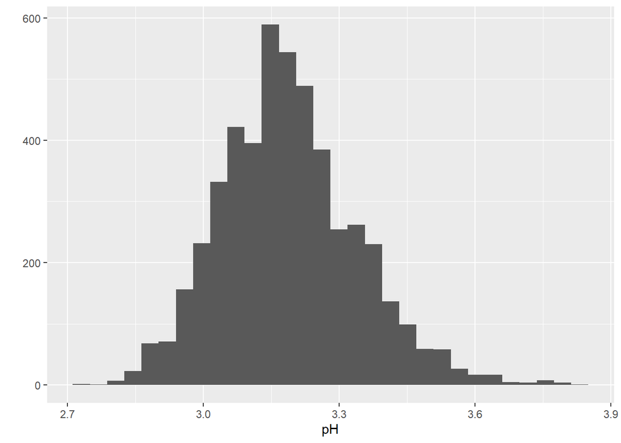

```r
qplot(x = pH, data = wd);
```

```r
summary(wd$pH)
```

```
##    Min. 1st Qu.  Median    Mean 3rd Qu.    Max.
##   2.720   3.090   3.180   3.188   3.280   3.820
```

The histgoram of pH is also normally distibuted and concentrated around 3.15. The min and max values are 2.72 and 3.82, the median is 3.18.

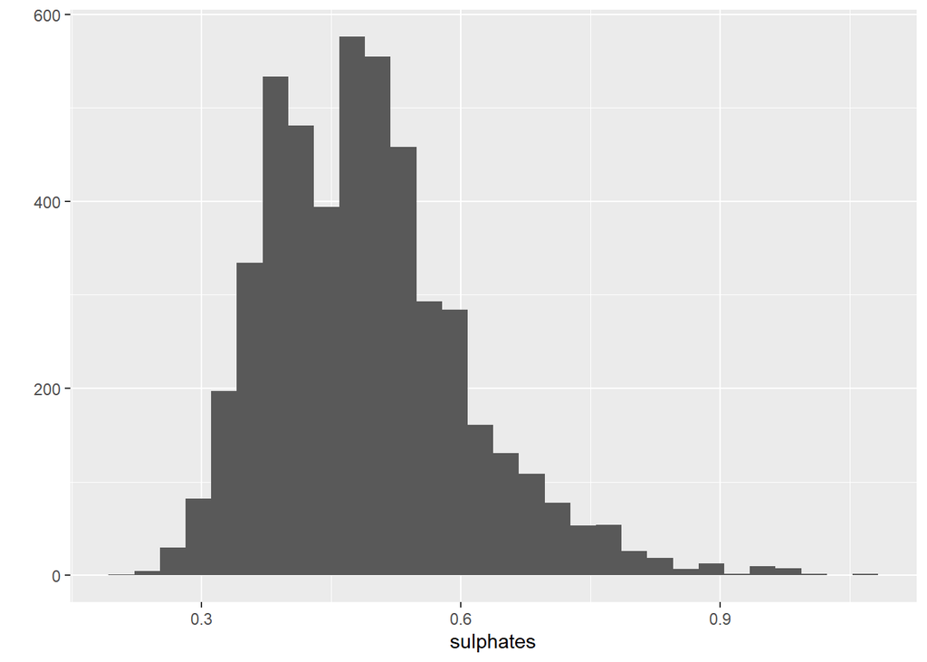

```r
qplot(x= sulphates, data = wd)
```

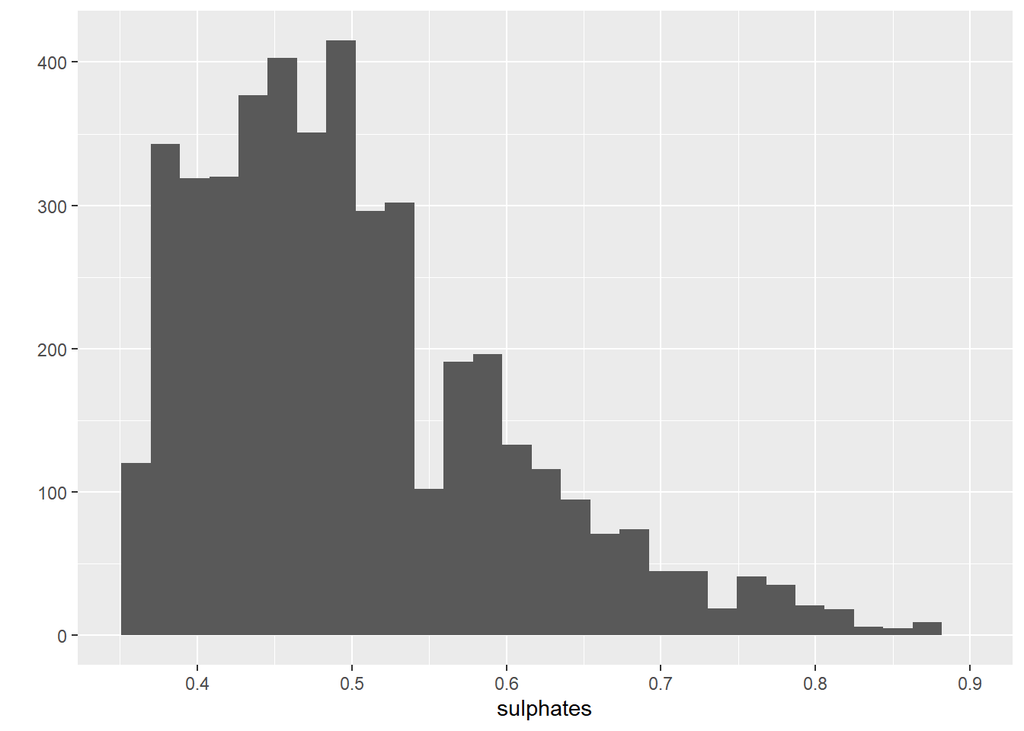

```r
qplot(x= sulphates, data = wd, xlim = c(0.35, 0.9));
```

```r
summary(wd$sulphates)
```

```
##    Min. 1st Qu.  Median    Mean 3rd Qu.    Max.
##  0.2200  0.4100  0.4700  0.4898  0.5500  1.0800
```

The histogram of suplhate content is right skewed - the most oftten occuring values are between 0.4 and 0.5, the peak is about 400. I used an xlim function to improve readability and remove outstanding values.

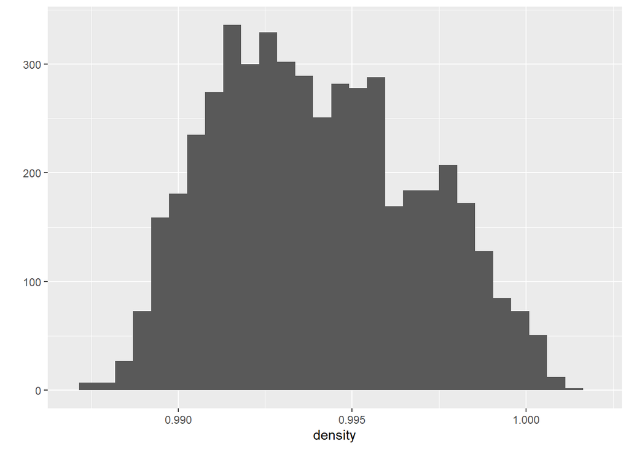

```r
qplot(x= density, data = wd, xlim = c(0.987, 1.002))
```

```r
summary(wd$density)
```

```
##    Min. 1st Qu.  Median    Mean 3rd Qu.    Max.
##  0.9871  0.9917  0.9937  0.9940  0.9961  1.0390
```

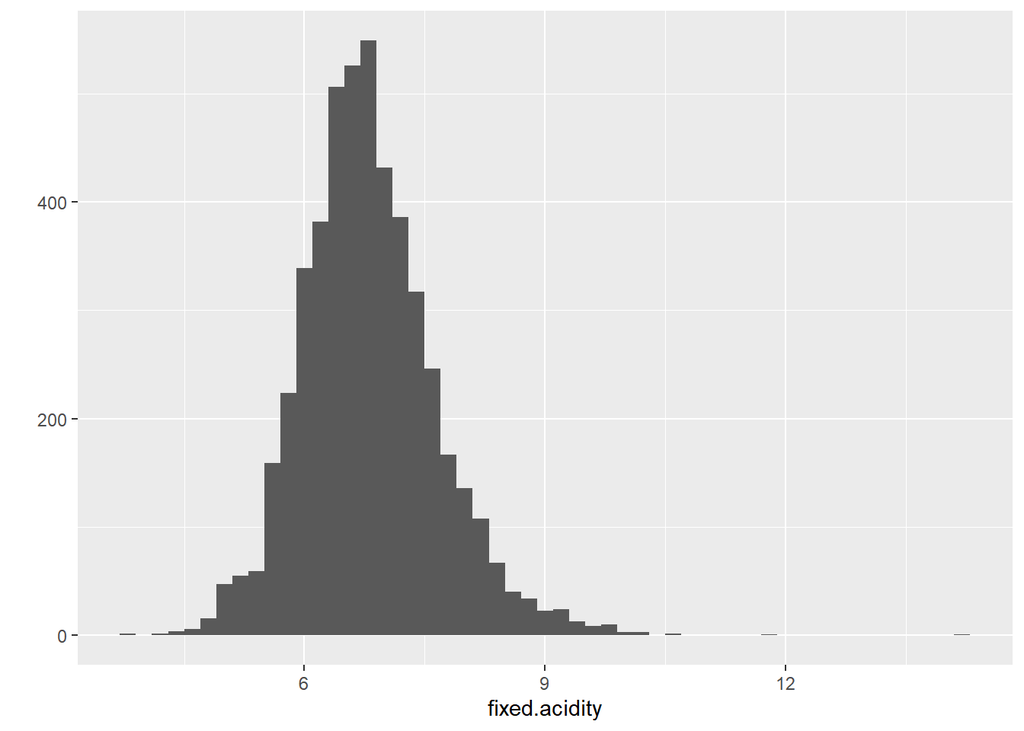

```r
qplot(x= fixed.acidity, data = wd, binwidth = 0.2)
```

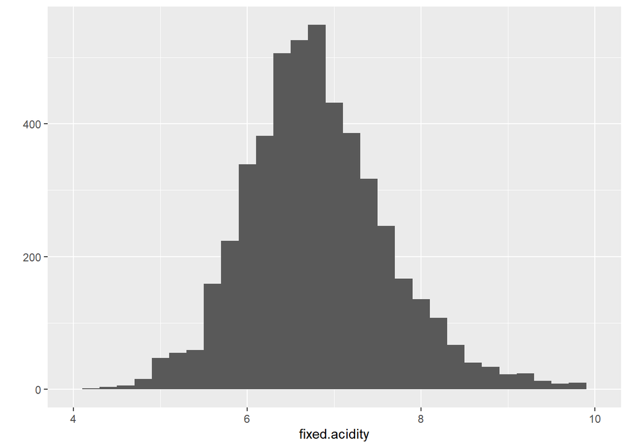

```r
qplot(x= fixed.acidity, data = wd, binwidth = 0.2, xlim = c(4, 10))
```

```r
summary(wd$fixed.acidity)
```

```
##    Min. 1st Qu.  Median    Mean 3rd Qu.    Max.
##   3.800   6.300   6.800   6.855   7.300  14.200
```

The ditribution of fixed acidity has its peak around 7 and skeewed to the right. I removed the outliers with xlim on the second plot.

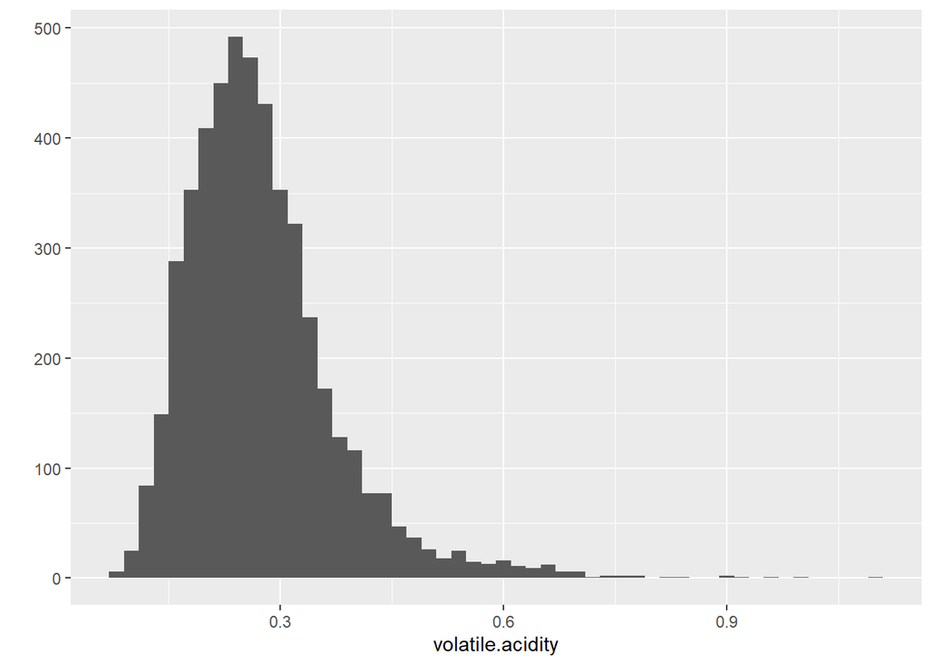

```r
qplot(x= volatile.acidity, data = wd, binwidth = 0.02)
```

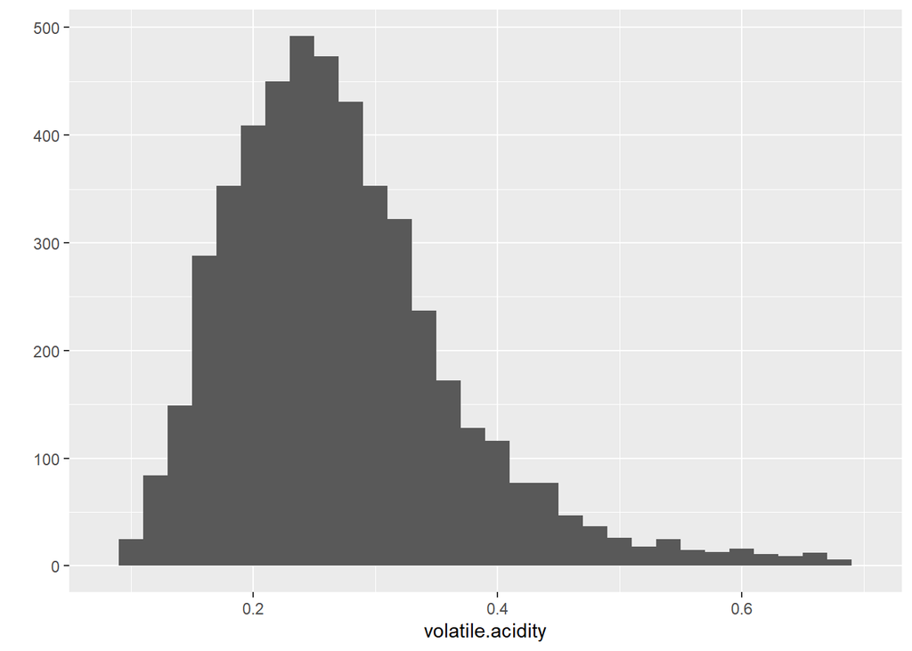

```r
qplot(x= volatile.acidity, data = wd, binwidth = 0.02, xlim= c(0.08, 0.7))
```

```r
summary(wd$volatile.acidity)
```

```
##    Min. 1st Qu.  Median    Mean 3rd Qu.    Max.
##  0.0800  0.2100  0.2600  0.2782  0.3200  1.1000
```

The histogram of volatile acidity is concentrated around 0.2 and skewed to the right. The most values are lacated between 0.15 and 0.325. I transformed the second plot with xlim to limit the outliers.

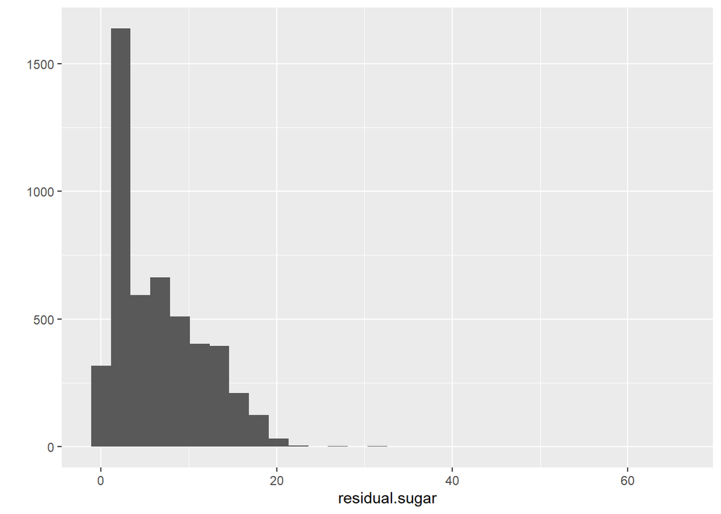

```r
qplot(x= residual.sugar, data = wd)
```

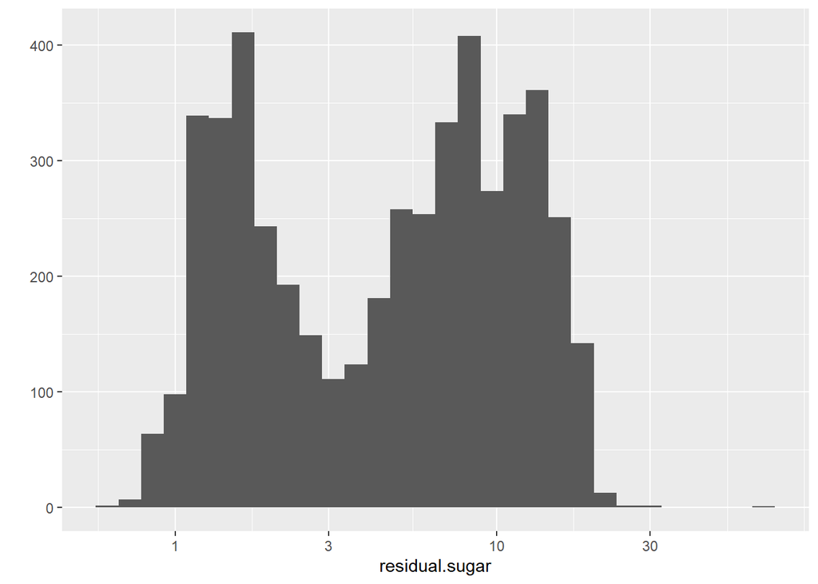

```r
qplot(x= residual.sugar, data = wd) +
  scale_x_log10()
```

```r
summary(wd$residual.sugar)
```

```
##    Min. 1st Qu.  Median    Mean 3rd Qu.    Max.
##   0.600   1.700   5.200   6.391   9.900  65.800
```

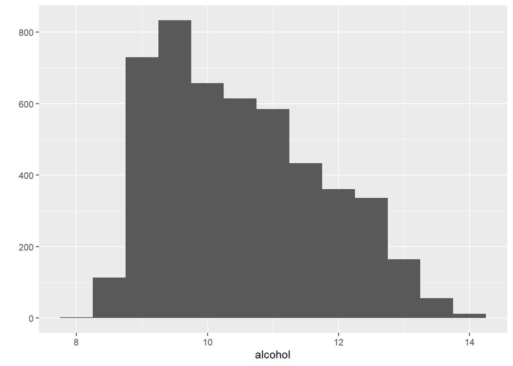

```r
qplot(x= alcohol, data = wd, binwidth = 0.5)
```

```r
summary(wd$alcohol)
```

```
##    Min. 1st Qu.  Median    Mean 3rd Qu.    Max.
##    8.00    9.50   10.40   10.51   11.40   14.20
```

The distribution of alcohol is right skewed, most wine have their alcohol content between 8.5 and 11. There is no wine with lower alcohol content that 8, and the maximum alcohol content is a little above 14. I setted the bidwidt to 0.5 for a better look.

### Bivariate Plots

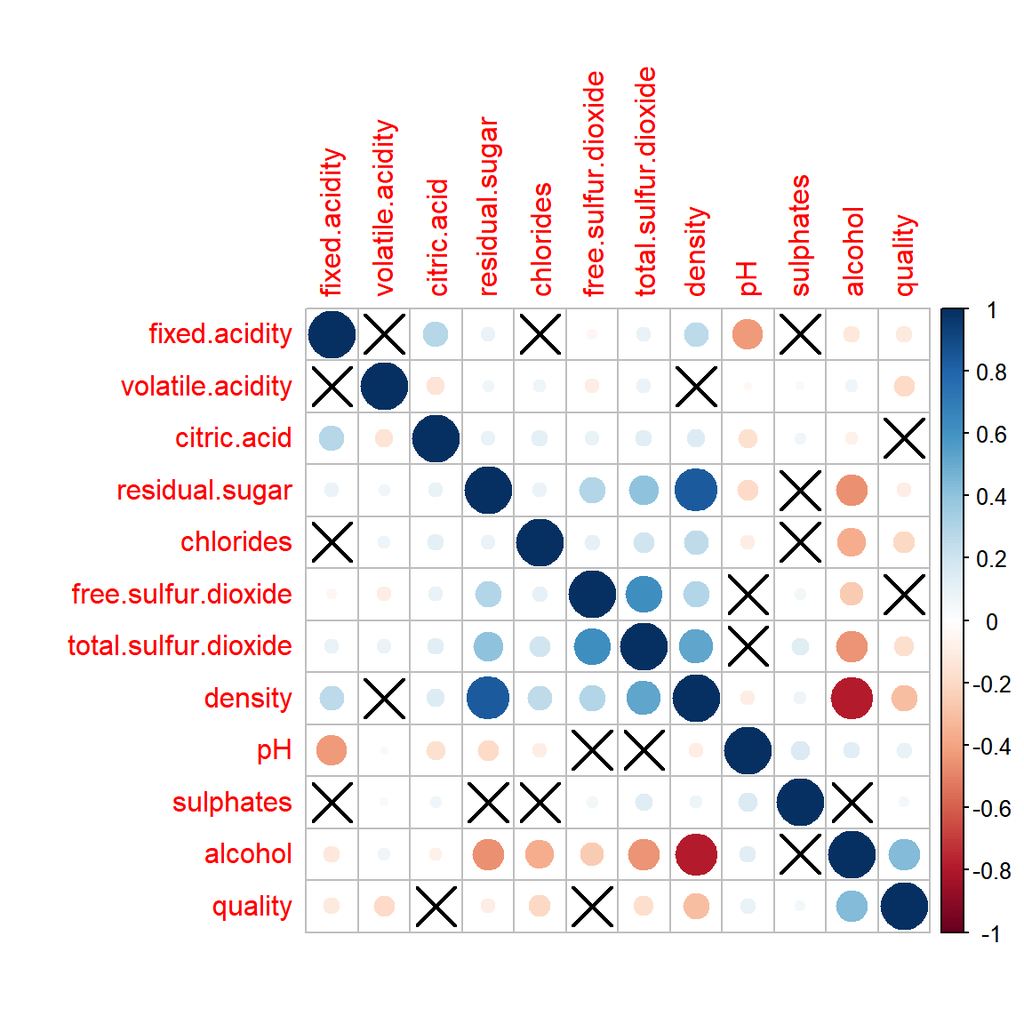

```r
corr_wine <- cor(wd)
sign <- cor.mtest(wd, conf.level = 0.95)
corrplot(corr_wine, method = 'circle', c1.pos = 'b',
         p.mat = sign$p, sig.level = 0.05, t1.col = "black" )
```

I plotted the variables of the dataset to get a quick visualization about which values are relevant in predicting wine quality. Based on the matrix, presume alcohol content to correlate with quality. Moreover, I also found some other interesting connections worth looking at it. I sat up a 0.95 confidence level and a 0.05 significance and marked the corresponding variables with a black X.

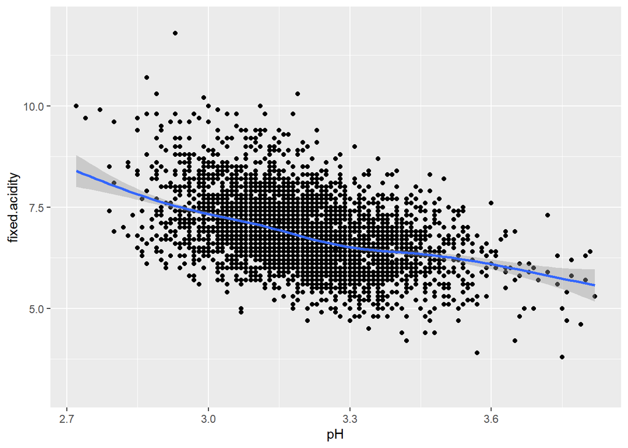

```r
ggplot(aes(x= pH, y = fixed.acidity), data = wd)+
  geom_point(aplha = 1/3)+
  scale_y_continuous(limits = c(3,12))+
  stat_smooth()
```

```r
cor(wd$pH, wd$fixed.acidity)
```

```
## [1] -0.4258583
```

I made a scatter plot diagram about the relationship between fixed acidity and pH. According to the visualization, the lower the fixed acidity, the higher the pH value, what absolutely makes sense. I also counted the correlation between the two variables and found a moderate negative relationship (-0.426) and used stat_smooth() function to represent it.

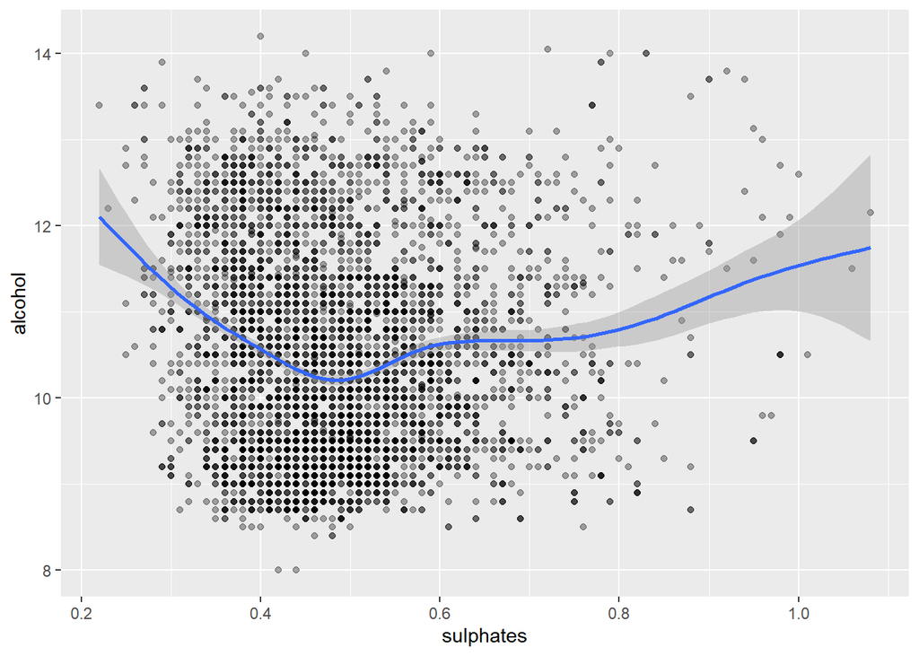

```r
ggplot(aes(x = sulphates, y = alcohol), data = wd)+
  geom_point(alpha = 1/3)+
  stat_smooth()
```

```r
cor(wd$sulphates, wd$alcohol)
```

```
## [1] -0.01743277
```

I created a scatter plot about sulphates and alcohol content. I did not found any correlation between the two vales, according to my correlation coefficient number, their correlation is just -0.017.

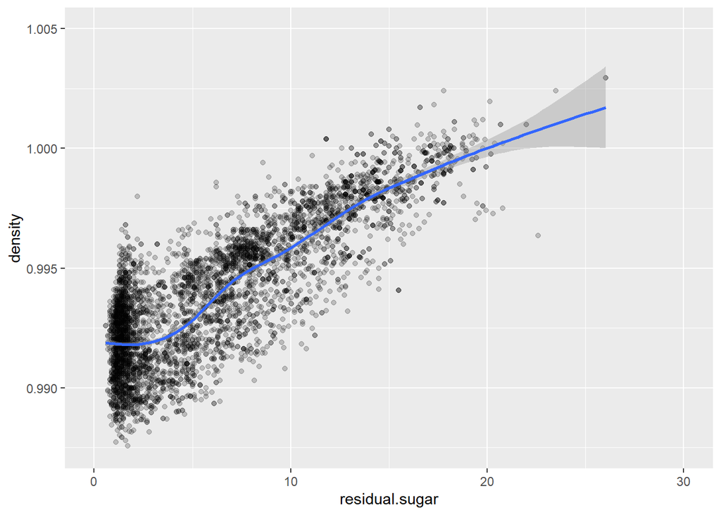

```r
ggplot(aes(x = residual.sugar, y = density), data = wd)+
  geom_point(alpha = 1/5) +
  scale_x_continuous(limits = c(0, 30)) +
  scale_y_continuous(limits = c(0.9875, 1.005)) +
  stat_smooth()
```

```r
cor(wd$density, wd$residual.sugar)
```

```
## [1] 0.8389665
```

I wondered if residual sugar can influence the density of a wine, so, I plotted the correlation between density and residual sugar and counted the correlation coefficient. I found a strong positive correlation between the two variables (0.839) - as sugar content increases, the density increases.

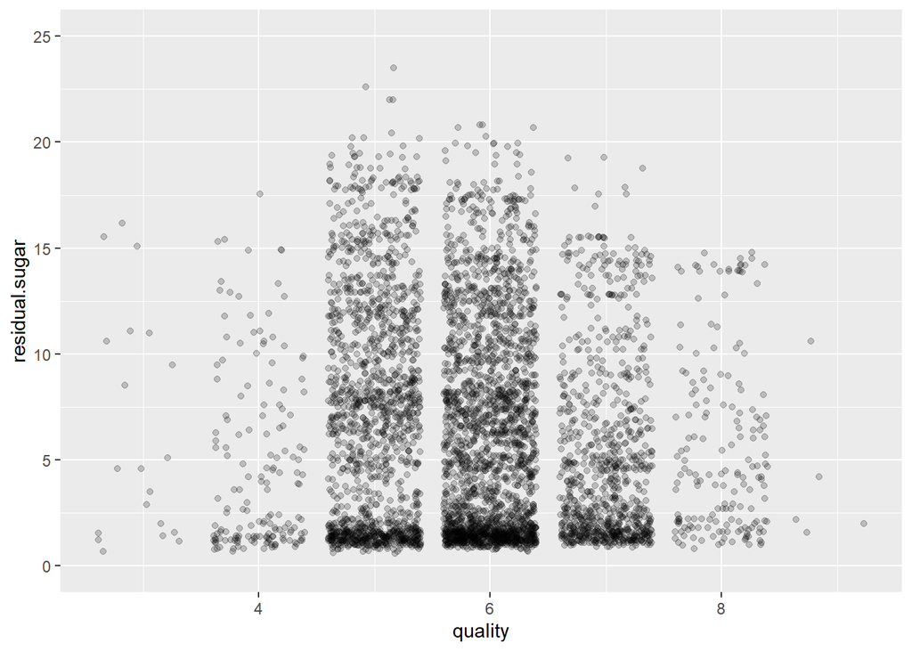

```r
ggplot(aes(x = quality, y = residual.sugar), data = wd)+
  geom_jitter(alpha = 0.2) +
  scale_y_continuous(limit = c(0, 25))
```

```r
cor(wd$quality, wd$residual.sugar)
```

```
## [1] -0.09757683
```

I created a jittering scatter plot about the correlation between residual sugar and quality. I did not find any correaltion between the two and the correlation coefficient was also quite week, only -0.0976. According to my results, I can state that there is no evidence that residual sugar would influence quality. This outcome does not match up with my expectations, I thought the best and most prestigous wines are dry and have a lower sugar content on the average.

```r
summaryBy(residual.sugar~quality, data=wd, FUN=c(mean))
```

```
##   quality residual.sugar.mean
## 1       3            6.392500
## 2       4            4.628221
## 3       5            7.334969
## 4       6            6.441606
## 5       7            5.186477
## 6       8            5.671429
## 7       9            4.120000
```

I used the summaryBy function from doBy package to summarize the residual sugar content by quality as I was curious about the more precise mean values.

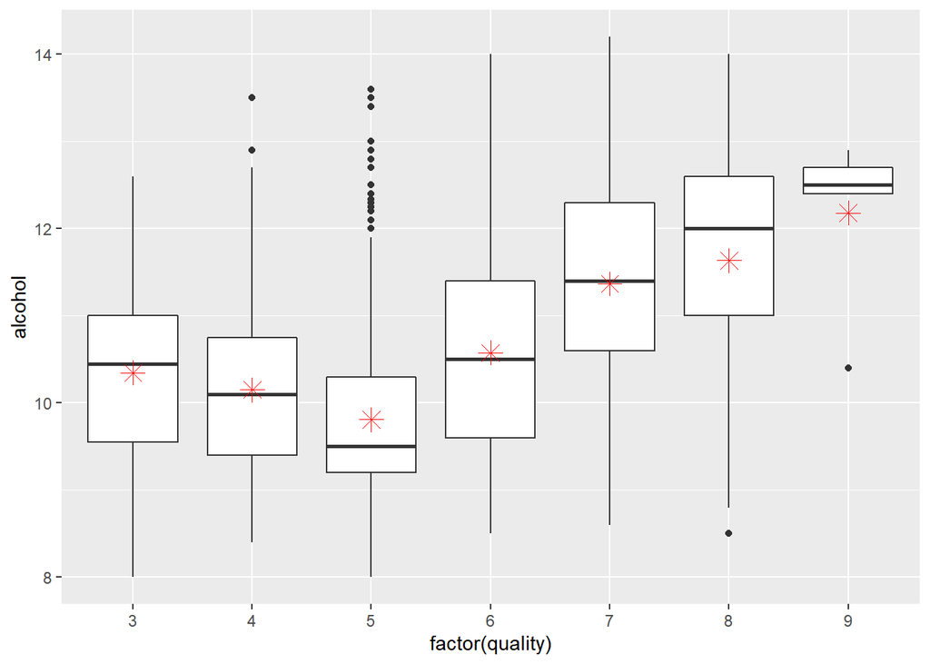

```r
ggplot(aes(x = factor(quality), y = alcohol), data = wd)+
  geom_boxplot() +
  stat_summary(fun.y = "mean",
               geom = "point",
               color = "red",
               shape = 8,
               size = 4)
```

```r
summaryBy(alcohol~quality, data=wd, FUN=c(mean, min, max))
```

```
##   quality alcohol.mean alcohol.min alcohol.max
## 1       3     10.34500         8.0        12.6
## 2       4     10.15245         8.4        13.5
## 3       5      9.80884         8.0        13.6
## 4       6     10.57537         8.5        14.0
## 5       7     11.36794         8.6        14.2
## 6       8     11.63600         8.5        14.0
## 7       9     12.18000        10.4        12.9
```

```r
cor(wd$alcohol, wd$quality)
```

```
## [1] 0.4355747
```

I used boxplots to visualize the correlation between quality and alcohol content. I counted the correlation coefficient and got a positive moderate correlation (0.435). The boxplots also show that higher quality wines have higher median alcohol content (above 11 and even 12), while lower quality wines have their median alcohol content around 10. The minimum and maximum values also follow this pattern: the worse wines are their maximum around 12-13 while the betters around 14.

### Multivariate Plots Section

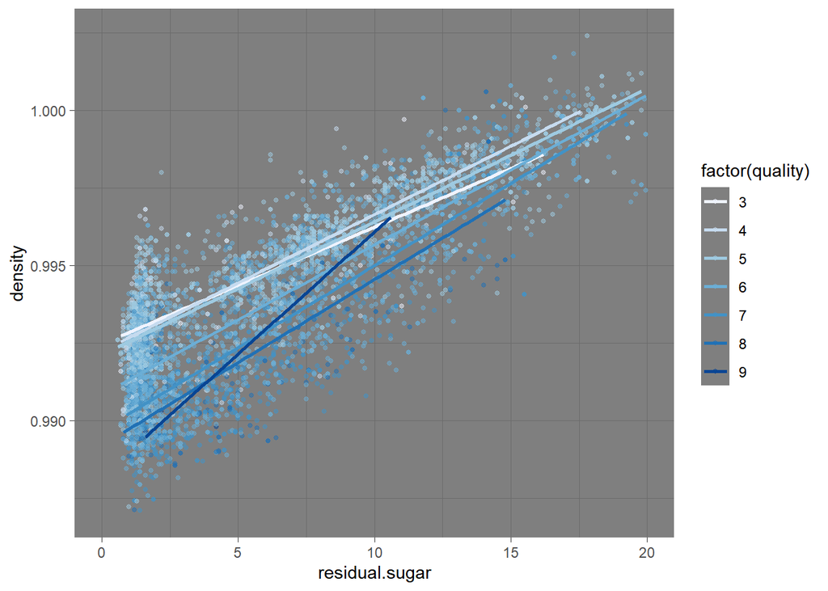

```r
ggplot(aes(x = residual.sugar,
           y = density, color = factor(quality)), data = wd) +
      geom_point(alpha = 0.5, size = 1) +
      geom_smooth(method = "lm", se = FALSE,size=1)  +
  scale_color_brewer(type='seq') +
  scale_y_continuous(limits = c(0.987, 1.0025)) +
  scale_x_continuous(limits = c(0, 20)) +
  theme_dark()
```

I created a scatter plot to investigate the interactions between residual sugar, density. I grouped and colored the dots by quality to show the correlation between density and quality, too. As a result, we got a strong positive correlated scatter plot where dots, representing the better wines can be found on the bottom of the plot. I also used regression lines and dark theme to make the trends easier to understand.

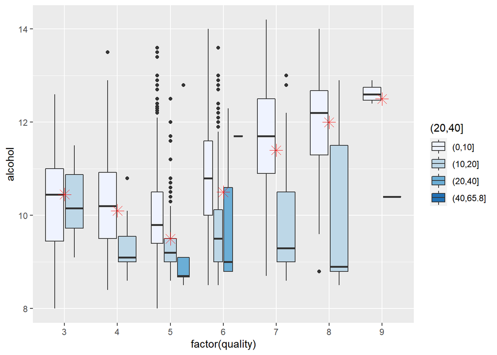

```r
wd$residual.sugar_bucket = cut(wd$residual.sugar,
                            c(0, 10, 20, 40, 65.800 ))
ggplot(aes(x = factor(quality), y = alcohol ), data = wd) +
  geom_boxplot( aes(fill= residual.sugar_bucket))  +
  scale_fill_brewer(type='seq',
                   guide=guide_legend(title=wd$residual.sugar_bucket))+
  stat_summary(fun.y = "median",
               geom = "point",
               color = "red",
               shape = 8,
               size = 4)
```

The opposite goes for the residual sugar, as wines with higher alcohol content contain less sugar. This tendency also reflects on one important part of wine making, as “residual sugar is the level of glucose and fructose (grape sugars) that are not converted into alcohol during fermentation”.

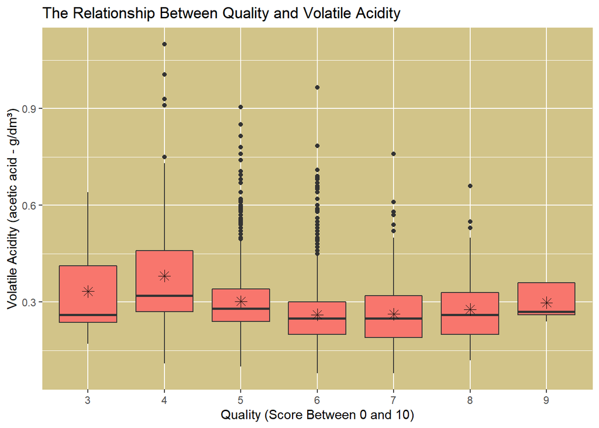

```r
plot1 <- ggplot(aes(x = factor(quality), y = volatile.acidity), data = wd)+
  geom_boxplot(aes(fill = "c13016"), show.legend = FALSE) +
  xlab('Quality (Score Between 0 and 10)') +
  ylab('Volatile Acidity (acetic acid - g/dm³)') +
  ggtitle('The Relationship Between Quality and Volatile Acidity') +
  stat_summary(fun.y = "mean",
               geom = "point",
               color = "black",
               shape = 8,
               size = 3)
plot1 +
  theme(
  panel.background = element_rect(fill = "#d2c489",
                                colour = "#d2c489"))
```

The visualization shows the correlation between volatile acidity and quality. We can not necessarily observe a linear trend among the quality ranges but the worst wines tend to have a higher volatile acidity, what absolutely makes sense: wines with higher volatile acidity could taste bad. If we compare the values between the first and third quantile we can see that the worst wines (quality 3 and 4) have higher volatile acidity while the better ones (quality 5-7) have lower values. This trend does not corresponds to the best wines (quality 8 and 9).

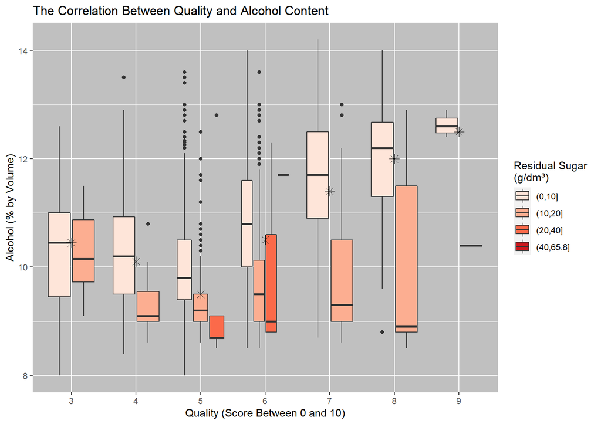

```r
plot2 <- ggplot(aes(x = factor(quality), y = alcohol ), data = wd) +
  geom_boxplot( aes(fill= residual.sugar_bucket))  +
  scale_fill_brewer(type='seq', palette = "Reds",
                   guide=guide_legend(title=wd$residual.sugar_bucket))+
  xlab('Quality (Score Between 0 and 10)') +
  ylab('Alcohol (% by Volume)') +
  ggtitle('The Correlation Between Quality and Alcohol Content') +
  stat_summary(fun.y = "median",
               geom = "point",
               color = "black",
               shape = 8,
               size = 3)
plot2 +
  theme(
  panel.background = element_rect(fill = "#C0C0C0",
                                colour = "#C0C0C0")) +
  guides(fill=guide_legend(title="Residual Sugar
(g/dm³)"))
```